# case study

2023-06-16

## Background

In 2016, Cyclistic launched a successful bike-share offering. Since then, the program has grown to a fleet of 5,824 bicycles that are geo-tracked and locked into a network of 692 stations across Chicago.

Until now, Cyclistic’s marketing strategy relied on building general awareness and appealing to broad consumer segments. One approach that helped make these things possible was the flexibility of its pricing plans: single-ride passes, full-day passes, and annual memberships. Customers who purchase single-ride or full-day passes are referred to as casual riders. Customers who purchase annual memberships are Cyclistic members.

It is understood that the goal can be broken down into 3 main questions.

How do annual members and casual riders use Cyclistic bikes differently? Why would casual riders buy Cyclistic annual memberships? How can Cyclistic use digital media to influence casual riders to become members? This report will seek to deliver on the following objectives:

How do annual members and casual riders use Cyclistic bikes differently?

cyclistic users, director of marketing, Cyclistic marketing team Cyclistic executive team

```r
library(tidyverse)
library(lubridate)
library(janitor)
```

```r
library(dplyr)
library(ggplot2)
```

### Load all the data, as well as combine every dataset

```r
trip20_Jan <- read.csv("C:\\Users\\Jiya\\Downloads\\archive\\202101-divvy-tripdata.csv")
trip20_Feb <- read.csv("C:\\Users\\Jiya\\Downloads\\archive\\202102-divvy-tripdata.csv")
trip20_Mar <- read.csv("C:\\Users\\Jiya\\Downloads\\archive\\202103-divvy-tripdata.csv")
trip20_Apr <- read.csv("C:\\Users\\Jiya\\Downloads\\archive\\202104-divvy-tripdata.csv")
trip20_May <- read.csv("C:\\Users\\Jiya\\Downloads\\archive\\202105-divvy-tripdata.csv")
trip20_Jun <- read.csv("C:\\Users\\Jiya\\Downloads\\archive\\202106-divvy-tripdata.csv")
trip20_Jul <- read.csv("C:\\Users\\Jiya\\Downloads\\archive\\202107-divvy-tripdata.csv")
trip20_Aug <- read.csv("C:\\Users\\Jiya\\Downloads\\archive\\202108-divvy-tripdata.csv")
trip20_Sep <- read.csv("C:\\Users\\Jiya\\Downloads\\archive\\202109-divvy-tripdata.csv")
trip20_Oct <- read.csv("C:\\Users\\Jiya\\Downloads\\archive\\202110-divvy-tripdata.csv")
trip20_Nov <- read.csv("C:\\Users\\Jiya\\Downloads\\archive\\202111-divvy-tripdata.csv")
trip20_Dec <- read.csv("C:\\Users\\Jiya\\Downloads\\archive\\202112-divvy-tripdata.csv")
```

### Combine every dataset to consolidate analysis

```r
trips20fill<- rbind(trip20_Jan, trip20_Feb, trip20_Mar, trip20_Apr, trip20_May, trip20_Jun, trip20_Jul, trip20_Aug, trip20_Sep, trip20_Oct, trip20_Nov, trip20_Dec)
```

### Firstly remove all the irrelevent columns that won’t be used for analysis

```r
trips20fill <- trips20fill %>%
  select(-c(start_lat, start_lng, end_lat, end_lng, start_station_id,end_station_id, end_station_name))
```

### Review of the data and its parameters.

```r
colnames(trips20fill)  #List of column names
```

```
## [1] "ride_id"            "rideable_type"      "started_at"
## [4] "ended_at"           "start_station_name" "member_casual"
```

```r
nrow(trips20fill)  #How many rows are in data frame?
```

```
## [1] 5595063
```

```r
dim(trips20fill)  #Dimensions of the data frame?
```

```
## [1] 5595063       6
```

```r
head(trips20fill, 6)  #See the first 6 rows of data frame.  Also tail(all_trips)
```

```
##            ride_id rideable_type          started_at            ended_at
## 1 E19E6F1B8D4C42ED electric_bike 2021-01-23 16:14:19 2021-01-23 16:24:44
## 2 DC88F20C2C55F27F electric_bike 2021-01-27 18:43:08 2021-01-27 18:47:12
## 3 EC45C94683FE3F27 electric_bike 2021-01-21 22:35:54 2021-01-21 22:37:14
## 4 4FA453A75AE377DB electric_bike 2021-01-07 13:31:13 2021-01-07 13:42:55
## 5 BE5E8EB4E7263A0B electric_bike 2021-01-23 02:24:02 2021-01-23 02:24:45
## 6 5D8969F88C773979 electric_bike 2021-01-09 14:24:07 2021-01-09 15:17:54
##           start_station_name member_casual
## 1 California Ave & Cortez St        member
## 2 California Ave & Cortez St        member
## 3 California Ave & Cortez St        member
## 4 California Ave & Cortez St        member
## 5 California Ave & Cortez St        casual
## 6 California Ave & Cortez St        casual
```

```r
str(trips20fill)  #See list of columns and data types (numeric, character, etc)
```

```
## 'data.frame':    5595063 obs. of  6 variables:
##  $ ride_id           : chr  "E19E6F1B8D4C42ED" "DC88F20C2C55F27F" "EC45C94683FE3F27" "4FA453A75AE377DB" ...
##  $ rideable_type     : chr  "electric_bike" "electric_bike" "electric_bike" "electric_bike" ...
##  $ started_at        : chr  "2021-01-23 16:14:19" "2021-01-27 18:43:08" "2021-01-21 22:35:54" "2021-01-07 13:31:13" ...
##  $ ended_at          : chr  "2021-01-23 16:24:44" "2021-01-27 18:47:12" "2021-01-21 22:37:14" "2021-01-07 13:42:55" ...
##  $ start_station_name: chr  "California Ave & Cortez St" "California Ave & Cortez St" "California Ave & Cortez St" "California Ave & Cortez St" ...
##  $ member_casual     : chr  "member" "member" "member" "member" ...
```

```r
summary(trips20fill) #inspect the date and its dimensions before moving onto cleaning
```

```
##    ride_id          rideable_type       started_at          ended_at
##  Length:5595063     Length:5595063     Length:5595063     Length:5595063
##  Class :character   Class :character   Class :character   Class :character
##  Mode  :character   Mode  :character   Mode  :character   Mode  :character
##  start_station_name member_casual
##  Length:5595063     Length:5595063
##  Class :character   Class :character
##  Mode  :character   Mode  :character
```

### Additional columns must be created for date and time.

```r
trips20fill$date <- as.Date(trips20fill$started_at)
trips20fill$month <- format(as.Date(trips20fill$date), "%m")
trips20fill$day <- format(as.Date(trips20fill$date), "%d")
trips20fill$year <- format(as.Date(trips20fill$date), "%Y")
trips20fill$day_of_week <- format(as.Date(trips20fill$date), "%A")
trips20fill$time <- format(trips20fill$started_at, format= "%H:%M")
trips20fill$time <- as.POSIXct(trips20fill$time, format= "%H:%M")
```

### Calculated filed that shows the time of each unique ride

```r
#create calculated field to isolate time spent on every ride.
trips20fill$ride_length <- (as.double(difftime(trips20fill$ended_at, trips20fill$started_at))) /60
```

## Check data structure. Confirm data types for time/date

```r
str(trips20fill) #confirm data type is double [True]
```

```
## 'data.frame':    5595063 obs. of  13 variables:
##  $ ride_id           : chr  "E19E6F1B8D4C42ED" "DC88F20C2C55F27F" "EC45C94683FE3F27" "4FA453A75AE377DB" ...
##  $ rideable_type     : chr  "electric_bike" "electric_bike" "electric_bike" "electric_bike" ...
##  $ started_at        : chr  "2021-01-23 16:14:19" "2021-01-27 18:43:08" "2021-01-21 22:35:54" "2021-01-07 13:31:13" ...
##  $ ended_at          : chr  "2021-01-23 16:24:44" "2021-01-27 18:47:12" "2021-01-21 22:37:14" "2021-01-07 13:42:55" ...
##  $ start_station_name: chr  "California Ave & Cortez St" "California Ave & Cortez St" "California Ave & Cortez St" "California Ave & Cortez St" ...
##  $ member_casual     : chr  "member" "member" "member" "member" ...
##  $ date              : Date, format: "2021-01-23" "2021-01-27" ...
##  $ month             : chr  "01" "01" "01" "01" ...
##  $ day               : chr  "23" "27" "21" "07" ...
##  $ year              : chr  "2021" "2021" "2021" "2021" ...
##  $ day_of_week       : chr  "Saturday" "Wednesday" "Thursday" "Thursday" ...
##  $ time              : POSIXct, format: NA NA ...
##  $ ride_length       : num  0 0 0 0 0 0 0 0 0 0 ...
```

```r
trips20fill$ride_length <- as.numeric(as.character(trips20fill$ride_length)) #change datatype to numeric for further analysis
```

```r
trips20fill<- trips20fill[!(trips20fill$start_station_name == "HQ QR" | trips20fill$ride_length<0),]
```

```r
summary(trips20fill$ride_length)
```

```
##     Min.  1st Qu.   Median     Mean  3rd Qu.     Max.
##     0.00     0.00     0.00    12.56     0.00 56160.00
```

### Calculating the mean, median, max, min - figures to determine statisical spead of membership type

```r
aggregate(trips20fill$ride_length ~ trips20fill$member_casual, FUN = mean)
```

```
##   trips20fill$member_casual trips20fill$ride_length
## 1                    casual               21.825935
## 2                    member                4.910083
```

```r
aggregate(trips20fill$ride_length ~ trips20fill$member_casual, FUN = median)
```

```
##   trips20fill$member_casual trips20fill$ride_length
## 1                    casual                       0
## 2                    member                       0
```

```r
aggregate(trips20fill$ride_length ~ trips20fill$member_casual, FUN = max)
```

```
##   trips20fill$member_casual trips20fill$ride_length
## 1                    casual                   56160
## 2                    member                    2940
```

```r
aggregate(trips20fill$ride_length ~ trips20fill$member_casual, FUN = min)
```

```
##   trips20fill$member_casual trips20fill$ride_length
## 1                    casual                       0
## 2                    member                       0
```

### Order day’s of week within new dataset for future use

```r
trips20fill$day_of_week <- ordered(trips20fill$day_of_week, levels=c("Sunday", "Monday", "Tuesday", "Wednesday", "Thursday", "Friday", "Saturday"))
```

### Create a weekday field as well as view column specifics

```r
trips20fill %>%
  mutate(day_of_week = wday(started_at, label = TRUE)) %>%  #creates weekday field using wday()
  group_by(member_casual, day_of_week ) %>%  #groups by usertype and weekday
  summarise(number_of_rides = n())
```

```
## # A tibble: 14 × 3
## # Groups:   member_casual [2]
##    member_casual day_of_week number_of_rides
##    <chr>         <ord>                 <int>
##  1 casual        Sun                  481143
##  2 casual        Mon                  286376
##  3 casual        Tue                  274392
##  4 casual        Wed                  278950
##  5 casual        Thu                  286064
##  6 casual        Fri                  364080
##  7 casual        Sat                  558000
##  8 member        Sun                  376142
##  9 member        Mon                  416212
## 10 member        Tue                  465513
## 11 member        Wed                  477192
## 12 member        Thu                  451524
## 13 member        Fri                  446428
## 14 member        Sat                  433047
```

## Data Visualiation’s

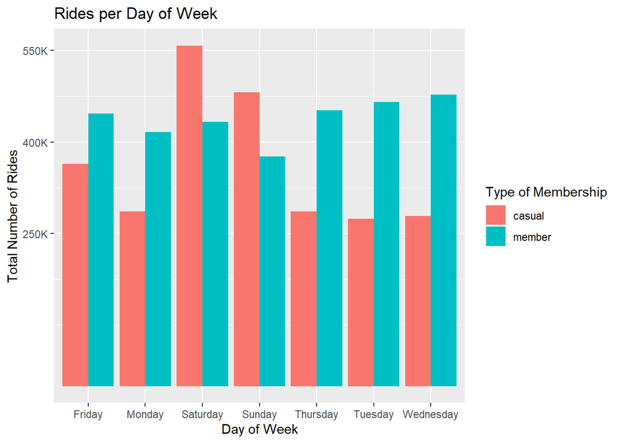

```r
trips20fill$day_of_week  <- format(as.Date(trips20fill$date), "%A")
trips20fill %>%                              #total rides broken down by weekday
  group_by(member_casual, day_of_week) %>%
  summarise(number_of_rides = n()) %>%
  arrange(member_casual, day_of_week) %>%
  ggplot(aes(x = day_of_week, y = number_of_rides, fill = member_casual)) + geom_col(position = "dodge") +
  labs(x='Day of Week', y='Total Number of Rides', title='Rides per Day of Week', fill = 'Type of Membership') +
  scale_y_continuous(breaks = c(250000, 400000, 550000), labels = c("250K", "400K", "550K"))
```

#### The rides per day of week show casual riders peak on the Saturday and Sunday while members peak Monday through Friday. This indicates members mainly use the bikes for their commutes and not leisure.

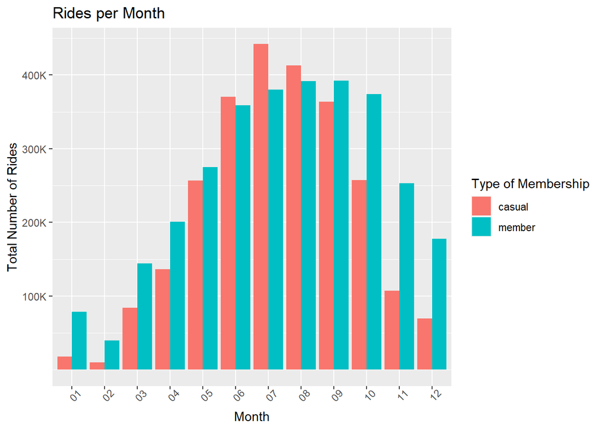

```r
trips20fill %>%   #total rides broken down by month
  group_by(member_casual, month) %>%
  summarise(total_rides = n(),`average_duration_(mins)` = mean(ride_length)) %>%
  arrange(member_casual) %>%
  ggplot(aes(x=month, y=total_rides, fill = member_casual)) + geom_col(position = "dodge") +
  labs(x= "Month", y= "Total Number of Rides", title = "Rides per Month", fill = "Type of Membership") +
  scale_y_continuous(breaks = c(100000, 200000, 300000, 400000), labels = c("100K", "200K", "300K", "400K")) + theme(axis.text.x = element_text(angle = 45))
```

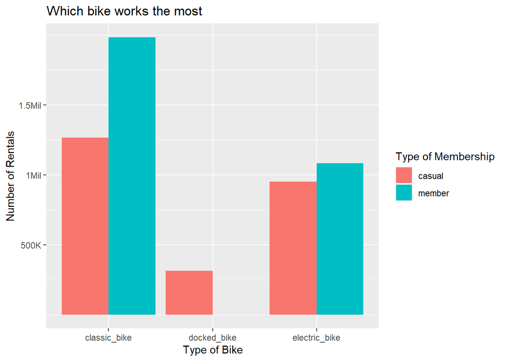

```r
trips20fill %>%    #looking at breakdown of bike types rented
  ggplot(aes(x = rideable_type, fill = member_casual)) + geom_bar(position = "dodge") +
  labs(x= 'Type of Bike', y='Number of Rentals', title='Which bike works the most', fill = 'Type of Membership') +
  scale_y_continuous(breaks = c(500000, 1000000, 1500000), labels = c("500K", "1Mil", "1.5Mil"))
```

#### The breakdown of which type of bike is the most popular among either type of user. Showing among the two types of bikes classic and electric. both types of memberships prefer using the classic bike more so than the electric bike. The long-term memebrs are also seen to be of the two types favours the classic bike.

[figure not shown]

```r
trips20fill %>%        #Find the average time spent riding by each membership type per individul day
  mutate(day_of_week = wday(started_at, label = TRUE)) %>%
  group_by(member_casual, day_of_week) %>%
  summarise(number_of_rides = n()
            ,average_duration = mean(ride_length)) %>%
  arrange(member_casual, day_of_week)  %>%
  ggplot(aes(x = day_of_week, y = average_duration, fill = member_casual)) +
  geom_col(position = "dodge") + labs(x='Days of the week', y='Average duration - Hrs', title='Average ride time per week', fill='Type of Membership')
```

### The average ride time shows a stark difference between the casuals and members. Casuals overall spend more time using the service than their full time member counter-parts.¶

## what does the data tell us?

### key takeaways

Casual users tended to ride more so in the warmer months of Chicago, namely June- August. Their participation exceeded that of the long term members. To further that the Casual demographic spent on average a lot longer time per ride than their long-term counter-parts. The days of the week also further shows that causal riders prefer to use the service during the weekends as their usage peaked then. The long term members conversly utilised the service more-so throughout the typical work week i.e (Monday- friday) Long term riders tended to stick more so to classic bikes as opposed to the docked or electric bikes.

## Recommendations

This report recommends the following: Introducing plans thats may be more appealing to casuals for the summer months. This marketing should be done during the winter months in preperation. The casual users might be more interested in a memebrship option that allows for per-use balance card. Alternatively, the existing payment structure may be altered in order to make single-use more costly to the casual riders as well as lowering the long-term membership rate. Membership rates specifically for the warmer months as well as for those who only ride on the weekends would assist in targeting the casual riders more specifically

### Things to Consider

Additional points that were not examined The report understands the scope of this analysis is extremely limited and because of that fact, additional data, as well as data points may have been able to contribute to this report offering an even more granular analysis. The following are data points that could have enhanced the report:

Age and gender: This would add a dynamic to whether or not customers are being targeted across demograpic lines. Is the existing marketing effective? Is there potential for more inclusive targeting?

Pricing structure: THe actual pricing plans data was not provided and would give further insight to which plans are the most popular and by (how much) when comparing them. It would also be effective to understanding the spending behaviour of casual user.

Household income data: Pinpointing the average income of the long-term memebrs as compared to the casual counter-parts would allow for further analysis of what is the typical economic standing of each type of member, as well as providing the ability to analysis overall price sensitivity between the two different membership types.